# Bagging y Random Forests en R

# 1. Introducción

- El *bagging* y los *random forests* son extensiones de los árboles de decisión.
- Son ejemplos de los **métodos de ensamble**: estimamos varios modelos del mismo tipo y los combinamos para obtener mejores predicciones.
- Aquí construimos varios árboles, cada uno sobre una muestra *bootstrap* distinta de los datos de entrenamiento.
- La diferencia: en *random forests*, en cada nodo de cada árbol usamos solo un **subconjunto** de las características.
- Compararemos los tres métodos (árbol, *bagging*, *random forest*) con un ejemplo bancario: predecir qué clientes aceptan un depósito a plazo tras una llamada de mercadeo. Así el banco enfoca mejor sus recursos.

# 2. Datos

- Usaremos `bank.csv`, una versión de la base *Bank Marketing* (UCI), de una campaña de mercadeo telefónico de un banco portugués.
- Leemos con `stringsAsFactors = TRUE`. Esto es **importante**: si el *outcome* `y` no fuera un factor, `randomForest` haría regresión en vez de clasificación.

```r
bank <- read.csv("data/bank.csv", stringsAsFactors = TRUE)
```

```r
str(bank)
```

```
## 'data.frame':    41188 obs. of  20 variables:
##  $ age         : int  56 57 37 40 56 45 59 41 24 25 ...
##  $ job         : Factor w/ 12 levels "admin.","blue-collar",..: 4 8 8 1 8 8 1 2 10 8 ...
##  $ marital     : Factor w/ 4 levels "divorced","married",..: 2 2 2 2 2 2 2 2 3 3 ...
##  $ education   : Factor w/ 8 levels "basic.4y","basic.6y",..: 1 4 4 2 4 3 6 8 6 4 ...
##  $ default     : Factor w/ 3 levels "no","unknown",..: 1 2 1 1 1 2 1 2 1 1 ...
##  $ housing     : Factor w/ 3 levels "no","unknown",..: 1 1 3 1 1 1 1 1 3 3 ...
##  $ loan        : Factor w/ 3 levels "no","unknown",..: 1 1 1 1 3 1 1 1 1 1 ...
##  $ contact     : Factor w/ 2 levels "cellular","telephone": 2 2 2 2 2 2 2 2 2 2 ...
##  $ month       : Factor w/ 10 levels "apr","aug","dec",..: 7 7 7 7 7 7 7 7 7 7 ...
##  $ day_of_week : Factor w/ 5 levels "fri","mon","thu",..: 2 2 2 2 2 2 2 2 2 2 ...
##  $ duration    : int  261 149 226 151 307 198 139 217 380 50 ...
##  $ campaign    : int  1 1 1 1 1 1 1 1 1 1 ...
##  $ previous    : int  0 0 0 0 0 0 0 0 0 0 ...
##  $ poutcome    : Factor w/ 3 levels "failure","nonexistent",..: 2 2 2 2 2 2 2 2 2 2 ...
##  $ empvarrate  : num  1.1 1.1 1.1 1.1 1.1 1.1 1.1 1.1 1.1 1.1 ...
##  $ conspriceidx: num  94 94 94 94 94 ...
##  $ consconfidx : num  -36.4 -36.4 -36.4 -36.4 -36.4 ...
##  $ euribor3m   : num  4.86 4.86 4.86 4.86 4.86 ...
##  $ nremployed  : num  5191 5191 5191 5191 5191 ...
##  $ y           : Factor w/ 2 levels "no","yes": 1 1 1 1 1 1 1 1 1 1 ...
```

- Son 41.188 observaciones y 20 variables. La última, `y`, es el *outcome* (si el cliente adquiere o no el producto):

```r
prop.table(table(bank$y))
```

```
##
##        no       yes
## 0.8873458 0.1126542
```

- Cerca del 88.7% no acepta el producto y solo el 11.3% sí: la clase de interés es **minoritaria** (un caso de desbalance, que retomaremos más adelante).
- Siempre conviene conocer las variables:

```r
table(bank$marital)
```

```
##
## divorced  married   single  unknown
##     4612    24928    11568       80
```

```r
summary(bank$age)
```

```
##    Min. 1st Qu.  Median    Mean 3rd Qu.    Max.
##   17.00   32.00   38.00   40.02   47.00   98.00
```

```r
table(bank$job)
```

```
##
##        admin.   blue-collar  entrepreneur     housemaid    management
##         10422          9254          1456          1060          2924
##       retired self-employed      services       student    technician
##          1720          1421          3969           875          6743
##    unemployed       unknown
##          1014           330
```

# 3. Árbol de decisión

- Compararemos *bagging* y *random forests* contra un árbol de decisión simple (C5.0), como punto de partida:

```r
library(C50)
```

- Creamos las bases de entrenamiento (90%) y prueba (10%) de forma aleatoria, fijando la semilla:

```r
set.seed(123)
train_sample <- sample(41188, 37069)
bank_train <- bank[train_sample, ]
bank_test  <- bank[-train_sample, ]
```

- Verifiquemos que las proporciones del *outcome* se mantienen tras la aleatorización:

```r
prop.table(table(bank_train$y))
```

```
##
##        no       yes
## 0.8873182 0.1126818
```

```r
prop.table(table(bank_test$y))
```

```
##
##        no       yes
## 0.8875941 0.1124059
```

- Construyamos el árbol (excluyendo la columna 20, que es el *outcome*):

```r
bank_tree <- C5.0(bank_train[-20], bank_train$y)
bank_tree
```

```
##
## Call:
## C5.0.default(x = bank_train[-20], y = bank_train$y)
##
## Classification Tree
## Number of samples: 37069
## Number of predictors: 19
##
## Tree size: 341
##
## Non-standard options: attempt to group attributes
```

- Predecimos sobre la base de prueba y evaluamos con `gmodels`:

```r
library(gmodels)
bank_pred_tree <- predict(bank_tree, bank_test)
CrossTable(bank_test$y, bank_pred_tree, prop.chisq = FALSE, prop.c = FALSE, prop.r = FALSE,
           dnn = c("Real", "Pronóstico"))
```

```
##
##
##    Cell Contents
## |-------------------------|
## |                       N |
## |         N / Table Total |
## |-------------------------|
##
##
## Total Observations in Table:  4119
##
##
##              | Pronóstico
##         Real |        no |       yes | Row Total |
## -------------|-----------|-----------|-----------|
##           no |      3513 |       143 |      3656 |
##              |     0.853 |     0.035 |           |
## -------------|-----------|-----------|-----------|
##          yes |       194 |       269 |       463 |
##              |     0.047 |     0.065 |           |
## -------------|-----------|-----------|-----------|
## Column Total |      3707 |       412 |      4119 |
## -------------|-----------|-----------|-----------|
##
##
```

- La precisión total es alta (~91%), pero engaña: en los clientes que **sí** adquieren el producto (la clase de interés), el modelo se equivoca en cerca de la mitad. Veamos si mejoramos eso.

# 4. Bagging

- Bajo *bagging* tomamos muestras *bootstrap* de la base de entrenamiento, construimos un árbol con cada una, y combinamos por regla de la mayoría.
- Lo hacemos con el paquete `randomForest`, porque *bagging* es un caso particular de *random forest*: aquel en que se usan **todas** las características en cada nodo. Si no lo tienes instalado:

```r
install.packages("randomForest")
```

```r
library(randomForest)
```

- Usamos `randomForest()` excluyendo la columna 20 del *outcome*. Fijamos `mtry = 19` (todas las variables, para que sea *bagging*) e `importance = TRUE` para calcular la importancia de variables. Limitamos a `ntree = 100` árboles: como vimos en clase, las tasas de error se estabilizan antes de 100. Fijamos la semilla para reproducir:

```r
set.seed(123)
bank_bag <- randomForest(x = bank_train[-20], y = bank_train$y,
                         mtry = 19, ntree = 100, importance = TRUE)
bank_bag
```

```
##
## Call:
##  randomForest(x = bank_train[-20], y = bank_train$y, ntree = 100,      mtry = 19, importance = TRUE)
##                Type of random forest: classification
##                      Number of trees: 100
## No. of variables tried at each split: 19
##
##         OOB estimate of  error rate: 8.85%
## Confusion matrix:
##        no  yes class.error
## no  31506 1386  0.04213791
## yes  1895 2282  0.45367489
```

- La matriz de confusión que muestra se basa en las predicciones *out of bag* (OOB): para cada árbol, los casos que no entraron en su muestra *bootstrap*.
- Grafiquemos las tasas de error OOB según el número de árboles:

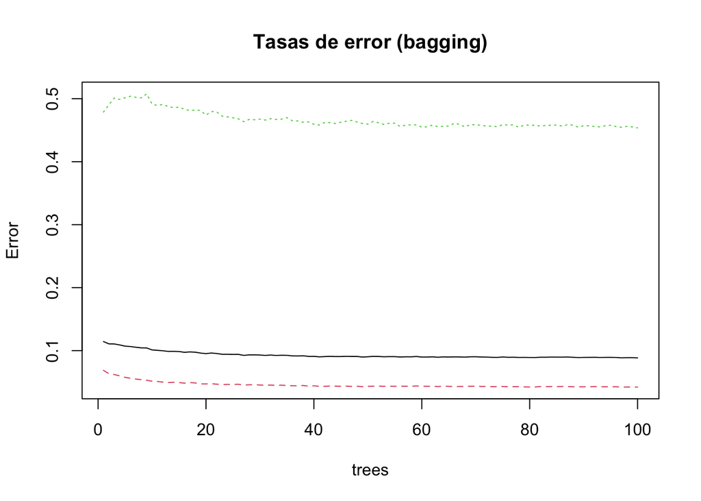

```r
plot(bank_bag, main = "Tasas de error (bagging)")
```

- Se observa que las tasas se estabilizan rápido. La clase minoritaria (clientes que sí adquieren) es la de mayor error.
- Veamos la importancia de las variables (*mean decrease in Gini*: la ganancia de información promedio de cada variable). Estos árboles usan el índice de Gini en lugar de la entropía, pero la intuición es la misma:

```r
round(importance(bank_bag, type = 2), 2)
```

```
##              MeanDecreaseGini
## age                    625.76
## job                    491.20
## marital                123.57
## education              346.28
## default                 45.81
## housing                 86.72
## loan                    77.89
## contact                 47.85
## month                  311.62
## day_of_week            333.57
## duration              2517.07
## campaign               267.20
## previous                89.15
## poutcome               162.22
## empvarrate              32.37
## conspriceidx            84.31
## consconfidx             72.96
## euribor3m              565.25
## nremployed            1134.93
```

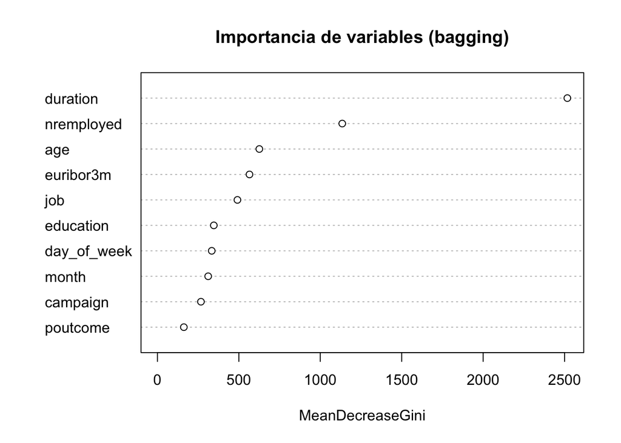

```r
varImpPlot(bank_bag, sort = TRUE, type = 2, n.var = 10, main = "Importancia de variables (bagging)")
```

- Predecimos sobre la base de prueba y comparamos:

```r
bank_pred_bag <- predict(bank_bag, bank_test)
CrossTable(bank_test$y, bank_pred_bag, prop.chisq = FALSE, prop.c = FALSE, prop.r = FALSE,
           dnn = c("real", "pronóstico"))
```

```
##
##
##    Cell Contents
## |-------------------------|
## |                       N |
## |         N / Table Total |
## |-------------------------|
##
##
## Total Observations in Table:  4119
##
##
##              | pronóstico
##         real |        no |       yes | Row Total |
## -------------|-----------|-----------|-----------|
##           no |      3518 |       138 |      3656 |
##              |     0.854 |     0.034 |           |
## -------------|-----------|-----------|-----------|
##          yes |       206 |       257 |       463 |
##              |     0.050 |     0.062 |           |
## -------------|-----------|-----------|-----------|
## Column Total |      3724 |       395 |      4119 |
## -------------|-----------|-----------|-----------|
##
##
```

# 5. Random Forests

- ¿Y si usamos *random forests*? La diferencia: en cada nodo se selecciona aleatoriamente un subconjunto de variables (no todas), lo que **decorrelaciona** los árboles.
- Con `randomForest()` no especificamos `mtry`: el valor por defecto es $m=\sqrt{p}$. Mantenemos `ntree = 100` y la semilla:

```r
set.seed(123)
bank_rf <- randomForest(x = bank_train[-20], y = bank_train$y,
                        ntree = 100, importance = TRUE)
bank_rf
```

```
##
## Call:
##  randomForest(x = bank_train[-20], y = bank_train$y, ntree = 100,      importance = TRUE)
##                Type of random forest: classification
##                      Number of trees: 100
## No. of variables tried at each split: 4
##
##         OOB estimate of  error rate: 8.76%
## Confusion matrix:
##        no  yes class.error
## no  31646 1246  0.03788155
## yes  2003 2174  0.47953076
```

- Evolución de los errores e importancia de variables:

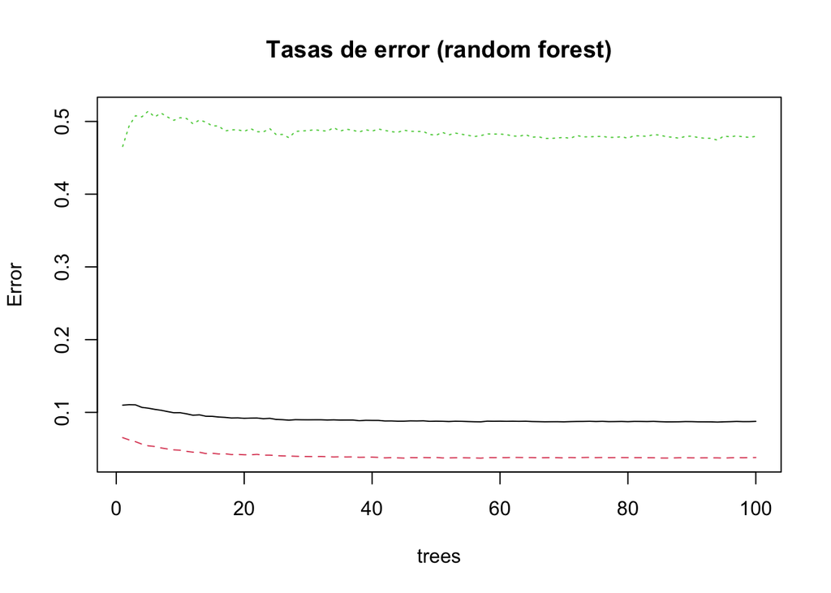

```r
plot(bank_rf, main = "Tasas de error (random forest)")
```

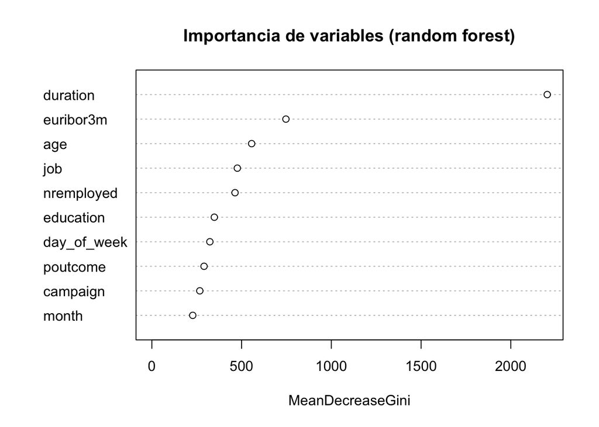

```r
varImpPlot(bank_rf, sort = TRUE, type = 2, n.var = 10, main = "Importancia de variables (random forest)")
```

- Y las predicciones sobre la base de prueba:

```r
bank_pred_rf <- predict(bank_rf, bank_test)
CrossTable(bank_test$y, bank_pred_rf, prop.chisq = FALSE, prop.c = FALSE, prop.r = FALSE,
           dnn = c("real", "pronóstico"))
```

```
##
##
##    Cell Contents
## |-------------------------|
## |                       N |
## |         N / Table Total |
## |-------------------------|
##
##
## Total Observations in Table:  4119
##
##
##              | pronóstico
##         real |        no |       yes | Row Total |
## -------------|-----------|-----------|-----------|
##           no |      3529 |       127 |      3656 |
##              |     0.857 |     0.031 |           |
## -------------|-----------|-----------|-----------|
##          yes |       218 |       245 |       463 |
##              |     0.053 |     0.059 |           |
## -------------|-----------|-----------|-----------|
## Column Total |      3747 |       372 |      4119 |
## -------------|-----------|-----------|-----------|
##
##
```